# R#2: introduction to Tidyverse

Laurent Modolo laurent.modolo@ens-lyon.fr

24 Oct 2019

# R#2: introduction to Tidyverse

The goal of this practical is to familiarize yourself with `ggplot2`.

The objectives of this session will be to:

- Create basic plot with `ggplot2`
- Understand the `tibble` type
- Learn the different aesthetics in R plots
- Compose graphics

# Tidyverse

The tidyverse is a collection of R packages designed for data science.

All packages share an underlying design philosophy, grammar, and data structures.

```r
install.packages("tidyverse")
```

```r
library("tidyverse")
```

# Toy data set `mpg`

This dataset contains a subset of the fuel economy data that the EPA makes available on **http://fueleconomy.gov**. It contains only models which had a new release every year between 1999 and 2008.

```r
?mpg
mpg
dim(mpg)
View(mpg)
```

# Updated version of the data

`mpg` is loaded with tidyverse, we want to be able to read our own data from **http://perso.ens-lyon.fr/laurent.modolo/R/2_data.csv**

```r
new_mpg <- read_csv(
  "http://perso.ens-lyon.fr/laurent.modolo/R/2_data.csv"
  )
```

**http://perso.ens-lyon.fr/laurent.modolo/R/2_a**

# First plot with `ggplot2`

Relationship between engine size `displ` and fuel efficiency `hwy`.

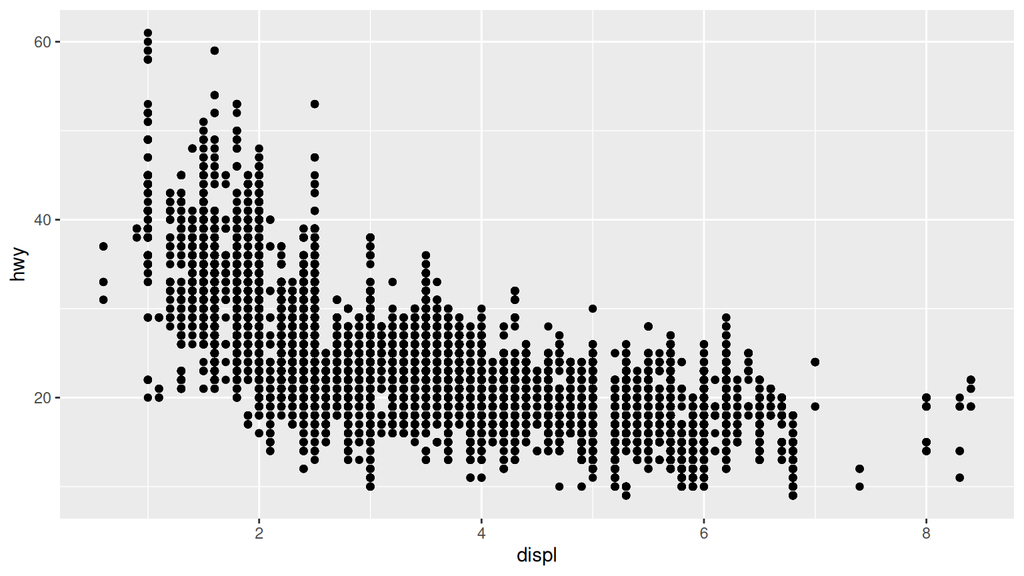

```r
ggplot(data = new_mpg) +
  geom_point(mapping = aes(x = displ, y = hwy))
```

# Composition of plot with `ggplot2`

Composition of plot with `ggplot2`

```r
ggplot(data = <DATA>) +
  <GEOM_FUNCTION>(mapping = aes(<MAPPINGS>))
```

- you begin a plot with the function `ggplot()`
- you complete your graph by adding one or more layers
- `geom_point()` adds a layer with a scatterplot
- each geom function in `ggplot2` takes a `mapping` argument
- the `mapping` argument is always paired with `aes()`

# First challenge

- Run `ggplot(data = new_mpg)`. What do you see?
- How many rows are in `new_mpg`? How many columns?
- What does the `cty` variable describe? Read the help for `?mpg` to find out.
- Make a scatterplot of `hwy` vs. `cyl`.
- What happens if you make a scatterplot of `class` vs. `drive`? Why is the plot not useful?

# Run `ggplot(data = mpg)`. What do you see?

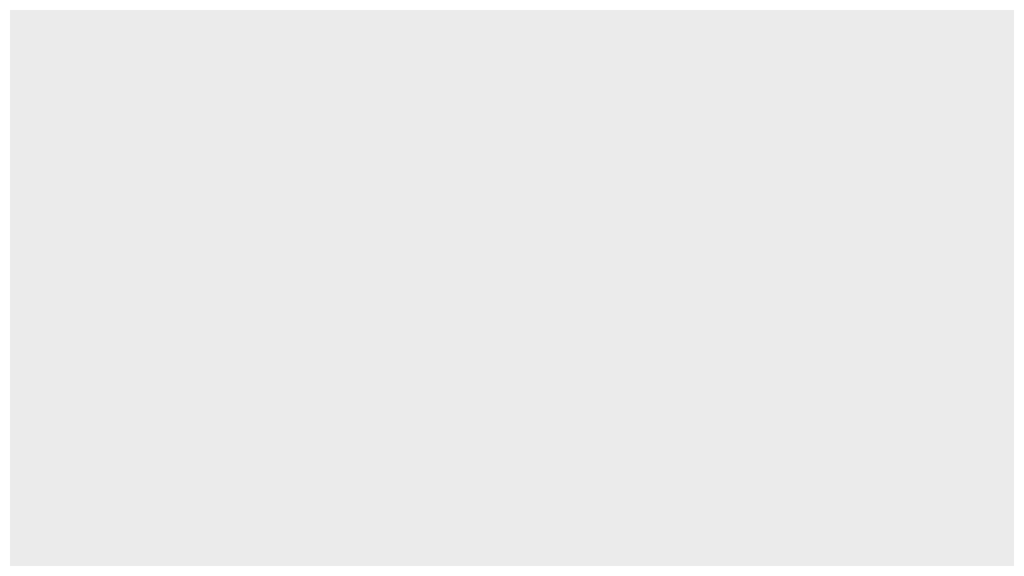

```r
ggplot(data = new_mpg)
```

# How many rows are in `new_mpg`? How many columns?

```r
new_mpg
```

```
## # A tibble: 40,440 x 12
##       id make  model   year class trans drive   cyl displ fuel    hwy   cty
##    <dbl> <chr> <chr>  <dbl> <chr> <chr> <chr> <dbl> <dbl> <chr> <dbl> <dbl>
##  1 13309 Acura 2.2CL…  1997 Subc… Auto… Fron…     4   2.2 Regu…    26    20
##  2 13310 Acura 2.2CL…  1997 Subc… Manu… Fron…     4   2.2 Regu…    28    22
##  3 13311 Acura 2.2CL…  1997 Subc… Auto… Fron…     6   3   Regu…    26    18
##  4 14038 Acura 2.3CL…  1998 Subc… Auto… Fron…     4   2.3 Regu…    27    19
##  5 14039 Acura 2.3CL…  1998 Subc… Manu… Fron…     4   2.3 Regu…    29    21
##  6 14040 Acura 2.3CL…  1998 Subc… Auto… Fron…     6   3   Regu…    26    17
##  7 14834 Acura 2.3CL…  1999 Subc… Auto… Fron…     4   2.3 Regu…    27    20
##  8 14835 Acura 2.3CL…  1999 Subc… Manu… Fron…     4   2.3 Regu…    29    21
##  9 14836 Acura 2.3CL…  1999 Subc… Auto… Fron…     6   3   Regu…    26    17
## 10 11789 Acura 2.5TL   1995 Comp… Auto… Fron…     5   2.5 Prem…    23    18
## # … with 40,430 more rows
```

# Make a scatterplot of `hwy` vs. `cyl`.

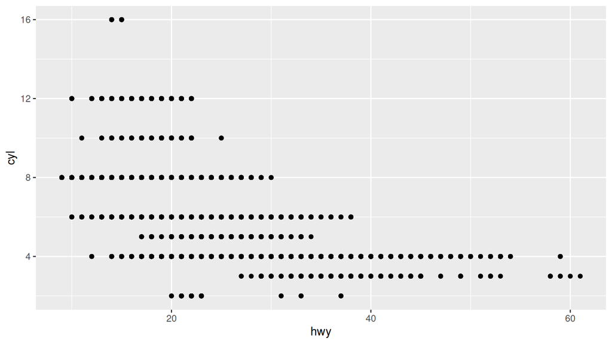

```r
ggplot(data = new_mpg) +
  geom_point(mapping = aes(x = hwy, y = cyl))
```

# What happens if you make a scatterplot of `class` vs. `drive`?

Why is the plot not useful?

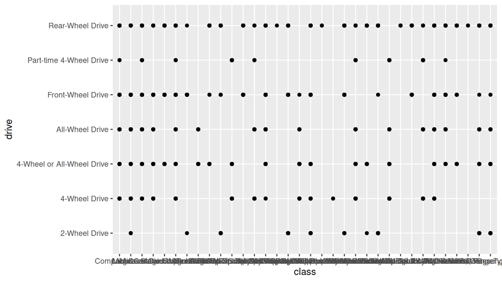

```r
ggplot(data = new_mpg) +
  geom_point(mapping = aes(x = class, y = drive))
```

# Aesthetic mappings

How can you explain these cars?

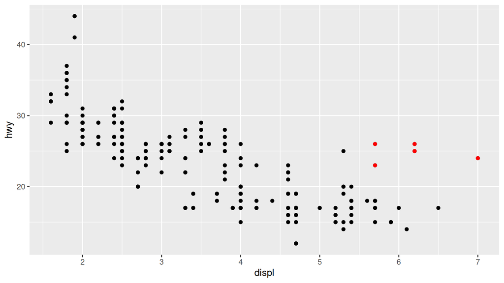

# Aesthetic mapping `color`

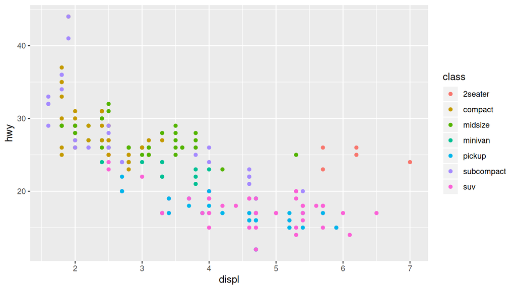

```r
ggplot(data = mpg) +
  geom_point(mapping = aes(x = displ, y = hwy, color = class))
```

# Aesthetic mappings

`ggplot2` will automatically assign a unique level of the aesthetic (here a unique color) to each unique value of the variable, a process known as scaling. `ggplot2` will also add a legend that explains which levels correspond to which values.

Try the following aesthetic:

- `size`
- `alpha`
- `shape`

# Aesthetic mapping `size`

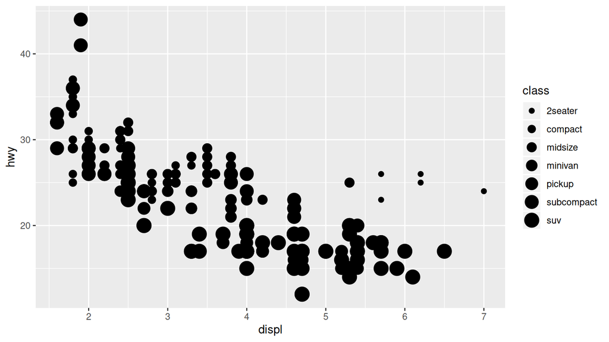

```r
ggplot(data = mpg) +
  geom_point(mapping = aes(x = displ, y = hwy, size = class))
```

# Aesthetic mapping `alpha`

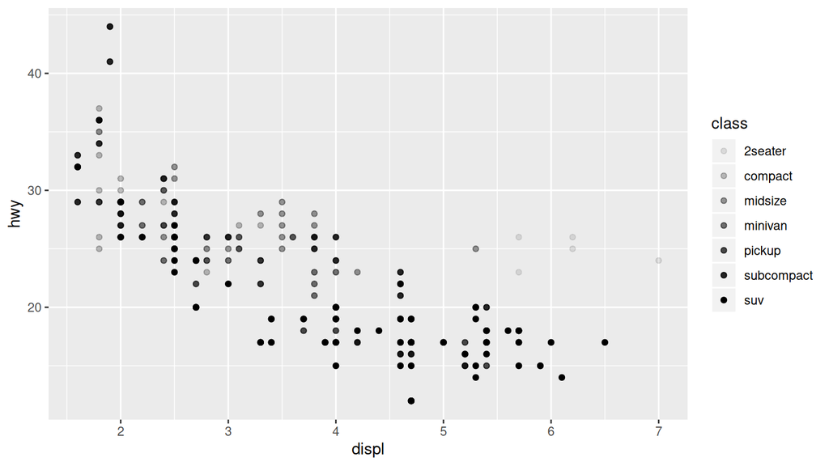

```r
ggplot(data = mpg) +
  geom_point(mapping = aes(x = displ, y = hwy, alpha = class))
```

# Aesthetic mapping `shape`

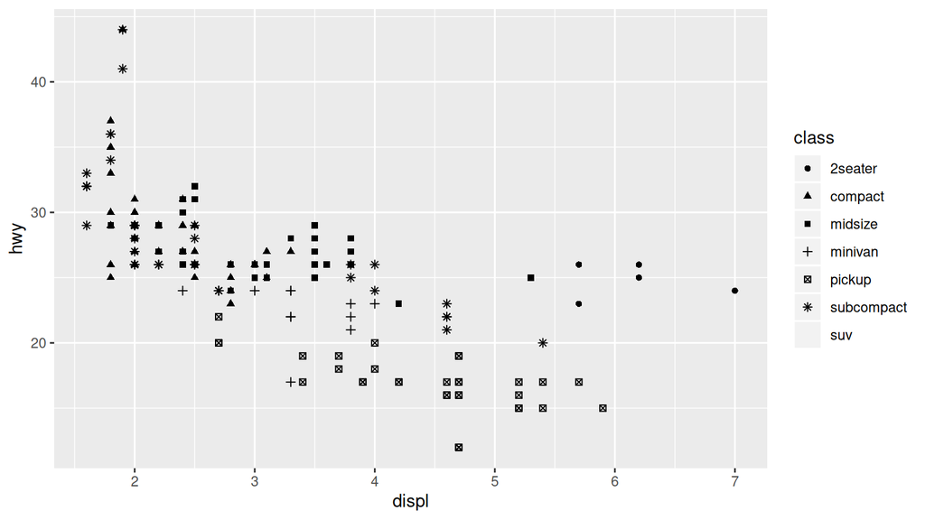

```r
ggplot(data = mpg) +
  geom_point(mapping = aes(x = displ, y = hwy, shape = class))
```

# Aesthetic

You can also set the aesthetic properties of your geom manually. For example, we can make all of the points in our plot blue:

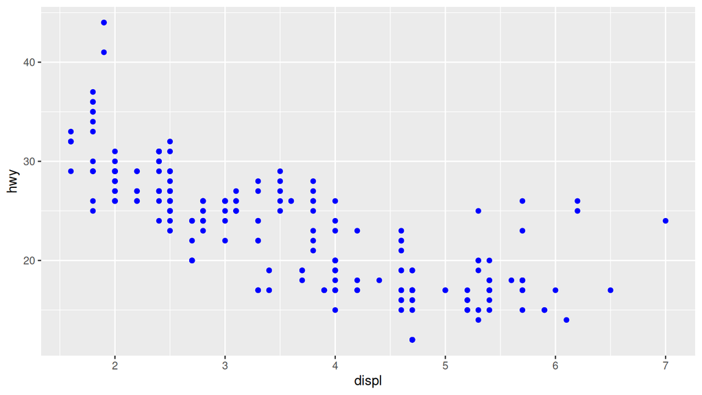

```r
ggplot(data = mpg) +
  geom_point(mapping = aes(x = displ, y = hwy), color = "blue")
```

# Second challenge

- What’s gone wrong with this code? Why are the points not blue?

```r
ggplot(data = mpg) +
  geom_point(mapping = aes(x = displ, y = hwy, color = "blue"))
```

- Which variables in `mpg` are **categorical**? Which variables are **continuous**? (Hint: type `mpg`)
- Map a **continuous** variable to color, size, and shape.
- What does the `stroke` aesthetic do? What shapes does it work with? (Hint: use ?geom_point)
- What happens if you map an aesthetic to something other than a variable name, like `color = displ < 5`?

# Facets

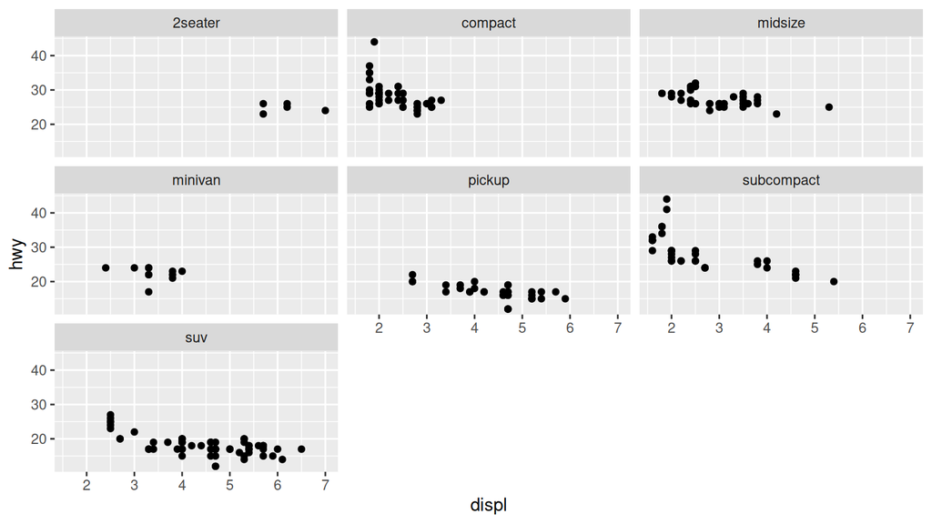

```r
ggplot(data = mpg) +
  geom_point(mapping = aes(x = displ, y = hwy)) +
  facet_wrap(~class)
```

# Facets

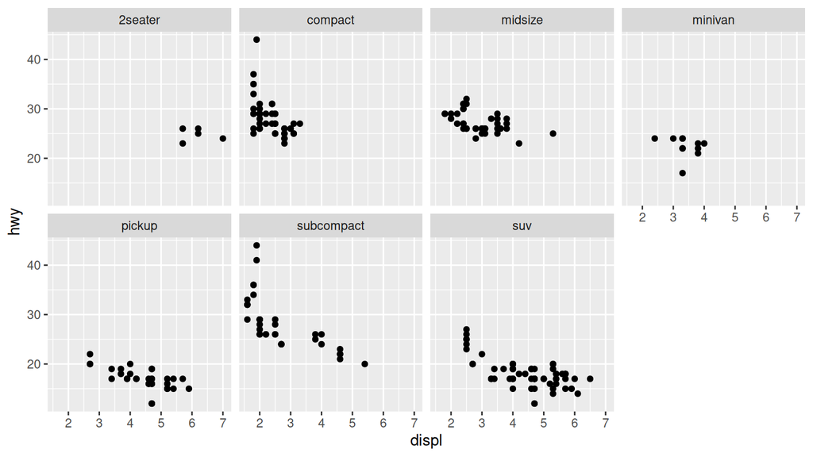

```r
ggplot(data = mpg) +
  geom_point(mapping = aes(x = displ, y = hwy)) +
  facet_wrap(~class, nrow = 2)
```

# Facets

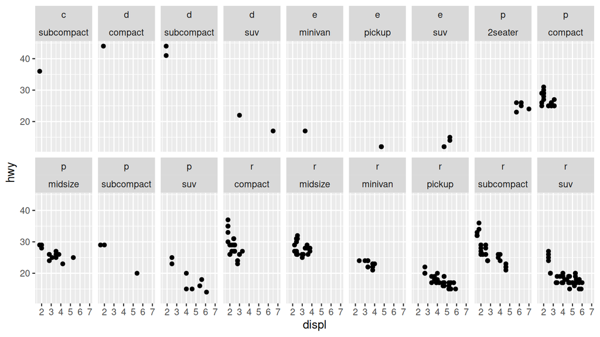

```r
ggplot(data = mpg) +
  geom_point(mapping = aes(x = displ, y = hwy)) +
  facet_wrap(~ fl + class, nrow = 2)
```

# Composition

There are different ways to represent the information

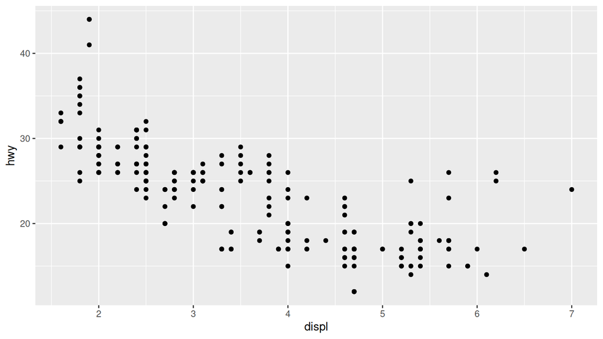

```r
ggplot(data = mpg) +
  geom_point(mapping = aes(x = displ, y = hwy))
```

# Composition

There are different ways to represent the information

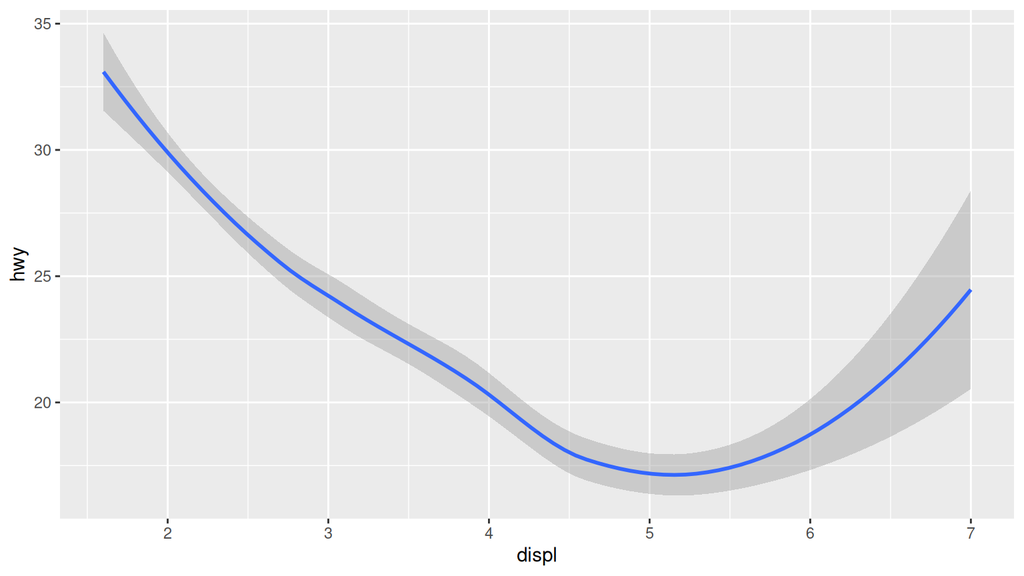

```r
ggplot(data = mpg) +
  geom_smooth(mapping = aes(x = displ, y = hwy))
```

# Composition

We can add as many layers as we want

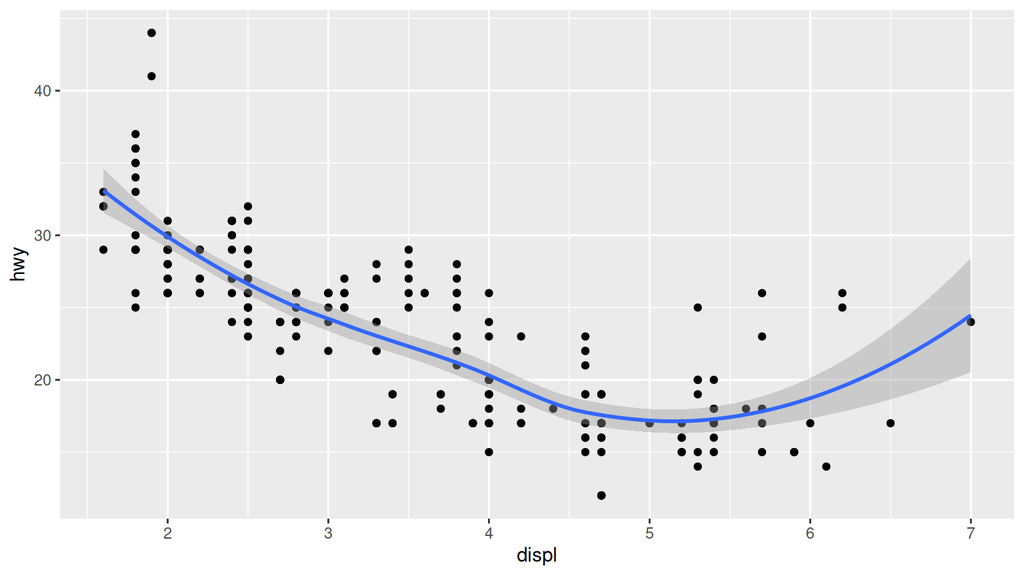

```r
ggplot(data = mpg) +
  geom_point(mapping = aes(x = displ, y = hwy)) +
  geom_smooth(mapping = aes(x = displ, y = hwy))
```

# Composition

We can avoid code duplication

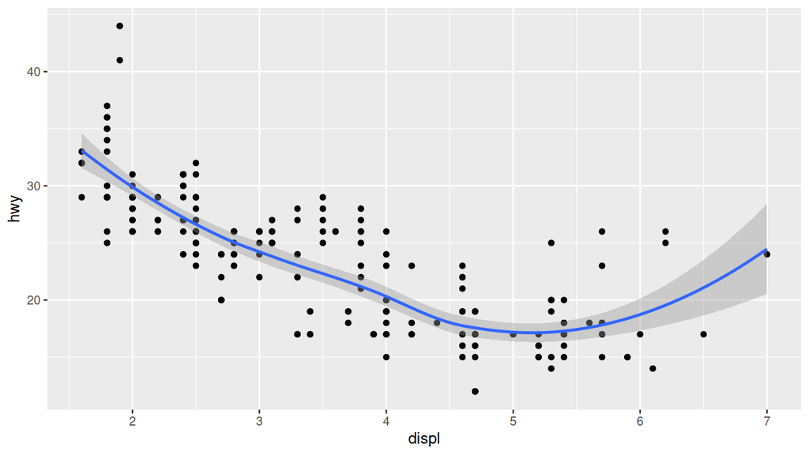

```r
ggplot(data = mpg, mapping = aes(x = displ, y = hwy)) +
  geom_point() +
  geom_smooth()
```

# Composition

We can make `mapping` layer specific

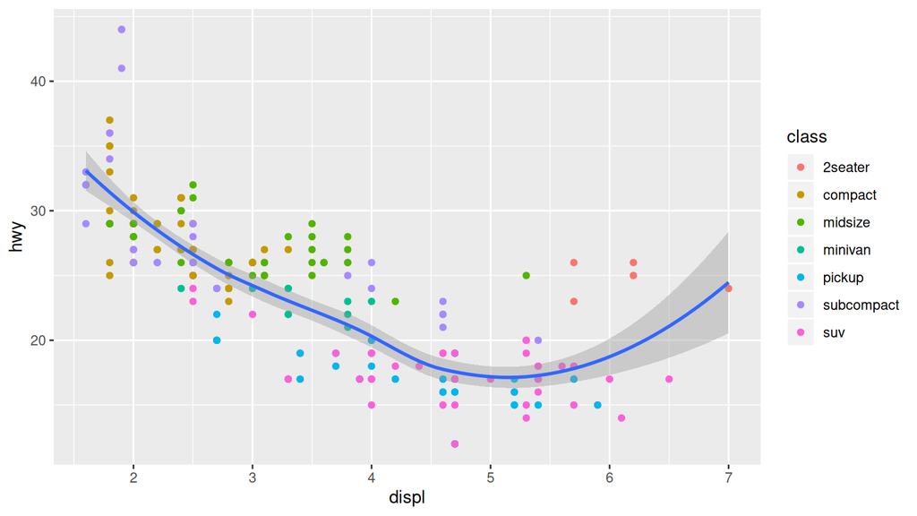

```r
ggplot(data = mpg, mapping = aes(x = displ, y = hwy)) +
  geom_point(mapping = aes(color = class)) +
  geom_smooth()
```

# Composition

We can use different `data` for different layer (You will lean more on `filter()` later)

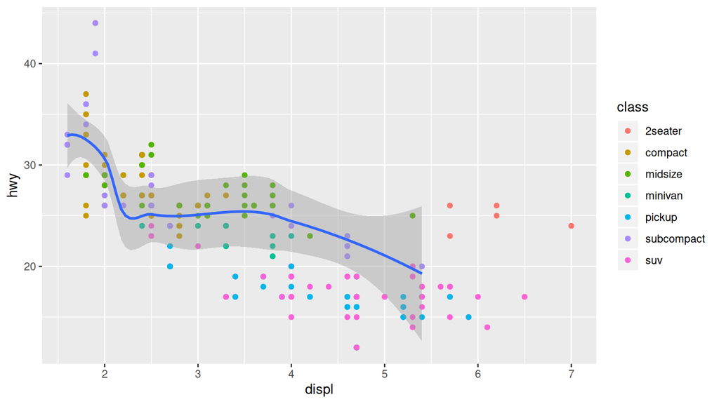

```r
ggplot(data = mpg, mapping = aes(x = displ, y = hwy)) +
  geom_point(mapping = aes(color = class)) +
  geom_smooth(data = filter(mpg, class == "subcompact"))
```

# Fird challenge

- Run this code in your head and predict what the output will look like. Then, run the code in R and check your predictions.

```r
ggplot(data = mpg, mapping = aes(x = displ, y = hwy, color = drv)) +
  geom_point() +
  geom_smooth(se = FALSE)
```

**http://perso.ens-lyon.fr/laurent.modolo/R/2_d**

- What does `show.legend = FALSE` do?
- What does the `se` argument to `geom_smooth()` do?

# Third challenge

- Recreate the R code necessary to generate the following graph

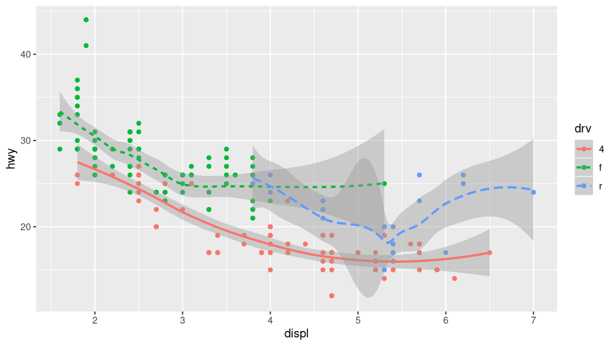

# Third challenge

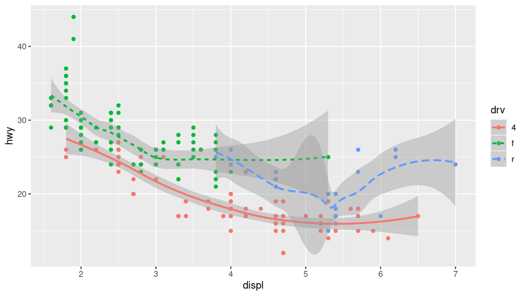

```r
ggplot(data = mpg, mapping = aes(x = displ, y = hwy, color = drv)) +
  geom_point() +
  geom_smooth(mapping = aes(linetype = drv))
```